# Quarto 2

Code-Chunk-Optionen und Querverweise

Autor:in

Zugehörigkeit

Daniela Palleschi

Humboldt-Universität zu Berlin

Veröffentlichungsdatum

30. Mai 2023

# Fragen zum Bericht

Geht zu menti.com und gebt den Code auf dem nächsten Bildschirm ein

# Update: Leistungspunkte

- Studienleistungen
  - 3LP
    - 1LP: Hochladen des wöchentlichen Programmierungsskripts (mindestens 8 von den 13 Wochen)
    - 1LP *2LP*: zwei “in-class” Übungen (je 0,5LP) *(je 1LP)*
    - 1LP: Hausarbeit (fällig am 15. August)

# Wiederholung

Letzte Woche haben wir…

- einen Bericht über Eye-Tracking-Lesedaten von Biondo et al. (2022) erstellt
- bekannte und neue Diagrammtypen interpretiert
- bekannte Darstellungsformen reproduziert

## Histogramm und Dichtediagramm

1. Was zeigen diese Diagramme?
   - Verteilung der Reaktionszeiten pro Genauigkeitsstufe
2. Was stellen die Spitzenwerte dar (z. B. Mittelwert, Median, Modus)?
   - die *Modus*-Reaktionszeit pro Genauigkeitsstufe
3. Gibt es einen (ungefähr) gleichen Anteil an richtigen (1) und falschen (0) Antworten? Wie kann man das feststellen?
   - Nein, es gibt viel mehr korrekte Antworten, das sieht man im Histogramm, das die Anzahl der Beobachtungen (y-Achse: Anzahl) pro Reaktionszeit-Bin (x-Achse) zeigt

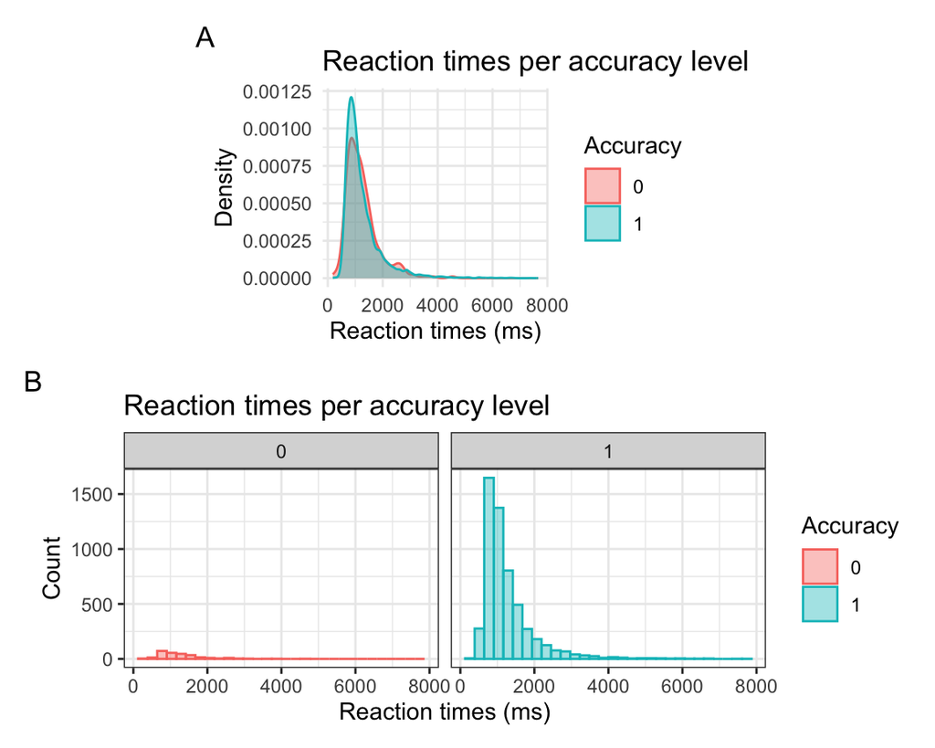

Abbildung 1: Dichte- und Histogrammdiagramme

# Heutige Ziele

Heute werden wir…

- lernen, wie man Code-Chunk-Optionen verwendet
- lernen, wie man die Größe von Abbildungen kontrolliert
- lernen, wie man Abbildungsunterschriften hinzufügt
- lernen, wie man formatierte Tabellen druckt
- lernen, wie man Querverweise erstellt

## Lust auf mehr?

- Ch. 29 ([Quarto](https://r4ds.hadley.nz/quarto.html)) in Wickham et al. (o. J.)
  - Absatz 29.5 ([Code Chunks](https://r4ds.hadley.nz/quarto.html#code-chunks))
  - Absatz 29.6 ([Figures](https://r4ds.hadley.nz/quarto.html#sec-figures))
  - Absatz 29.7 ([Tables](https://r4ds.hadley.nz/quarto.html#tables))

# 1 Einrichtung

1. Neuer Ordner für diese Woche
2. Neues Quarto-Dokument
3. YAML aktualisieren
4. Pakete laden
   - `tidyverse`
   - `knitr` (neu)
   - `kableExtra` (neu)
5. Ladet die Daten der Datei `flight.csv` ein

```r
pacman::p_load(tidyverse,
               knitr,
               kableExtra)
```

```r
df_flights <- read_csv(here::here("daten",
                                  "flights.csv"))
```

# 2 Code chunks

Abkürzungen:

- `Cmd/Strg+Alt+I`: neuen Code-Chunk einfügen
- `Cmd/Strg+Enter`: eine einzelne Code-Zeile ausführen
- `Cmd/Strg+Shift+Enter`: ganzen Code-Chunk ausführen
- Code Chunks sollten relativ in sich geschlossen (*self-contained*) sein
  - und auf eine einzige Aufgabe fokussiert sein

## 2.1 Chunk labels

- wir können jedem Code-Chunk Spezifikationen geben, indem wir `#|` *direkt* unter ````{r}`
  - `#| label: simple-math` wird den Chunk `simple-math` nennen

````markdown
```{r}
#| label: simple-math

4 + 4
```
````

```
[1] 8
```

### 2.1.1 Vorteile der Verwendung von Chunk-Labels

1. Über das Dropdown-Menü im Skript-Editor können wir zu bestimmten Code Chunks navigieren
2. Grafiken (z. B. Plots), die von Chunks erzeugt werden, erhalten nützliche Namen, die das spätere Auffinden erleichtern (mehr dazu in Kürze)

### 2.1.2 Chunk-Chunks sollten…

- kurz und informativ sein
- keine Leerzeichen enthalten (`-` oder `_` verwenden) *einmalig* im Dokument sein (nicht wiederholt)

**Eindeutige Chunk-Labels**

Chunk-Labels müssen innerhalb eines Skripts *immer* eindeutig sein!

- Wenn dies nicht der Fall ist, erhalten wir beim Rendern eine Fehlermeldung und das Dokument wird nicht gerendert
- Wir erhalten eine informative Fehlermeldung im Fenster ‘Background Jobs’, wenn wir doppelte Chunk-Labels haben, also *immer die Fehlermeldung lesen*! Sie können bei der Fehlersuche sehr hilfreich sein.

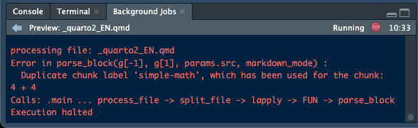

Abbildung 2: Error message when multiple code chunks have the same label `simple-math`

**Aufgabe 1: Chunk labels**

**Beispiel 1**

1. Fügt ein Chunk-Label zu eurem Code-Chunk hinzu, in den ihr Pakete geladen habt
2. Fügt einen Code Chunk mit dem Tastaturkürzel `Cmd/Strg-Alt-I` hinzu und fügt einige einfache mathematische Berechnungen hinzu
3. Fügt ein Chunk-Label hinzu
4. Probiert die Chunk-Navigationsleiste am unteren Rand des Quelltextfensters aus, um zwischen Code Chunks zu springen
5. Rendert das Dokument

## 2.2 Chunk-Optionen

Wird der folgende Codeabschnitt in der gerenderten Ausgabe erscheinen? Wird der Code ausgeführt werden?

````markdown
```{r}
#| eval: true
#| label: df-flights1
#| message: false

df_flights <- read_csv(here::here("daten", "flights.csv"))
```
````

Wird der folgende Codeabschnitt in der gerenderten Ausgabe erscheinen? Wird der Code ausgeführt werden?

````markdown
```{r}
#| eval: false
#| label: df-flights2
#| message: false

fig_flights <- read_csv(here::here("daten", "flights.csv")) %>%
  filter(month == 12) %>%
  ggplot(aes(x = dep_delay, y = arr_delay, colour = carrier)) +
  geom_point() +
  theme_minimal()
```
````

Die folgende Tabelle fasst zusammen, welche Arten von Ausgaben jede Option *unterdrückt*:

| Option | Run code | Show code | Output | Plots | Messages | Warnings |
| --- | --- | --- | --- | --- | --- | --- |
| `eval: false` | X |  | X | X | X | X |
| `include: false` |  | X | X | X | X | X |
| `echo: false` |  | X |  |  |  |  |
| `results: hide` |  |  | X |  |  |  |
| `fig-show: hide` |  |  |  | X |  |  |
| `message: false` |  |  |  |  | X |  |
| `warning: false` |  |  |  |  |  | X |

- Für den Rest des Kurses werden wir nur noch `eval`, `echo`, `include` und `message` verwenden

## 2.3 Globale Optionen

- die eben erwähnten Chunk-Optionen können auch *global* für euer gesamtes Dokument gesetzt werden, indem ihr sie in eurer YAML unter `excute:` hinzufügen

```r
title: "My report"
format:
  html:
    toc: true
execute:
  echo: false
```

- und dann können nachfolgende Code-Chunks die globale Einstellung von Fall zu Fall außer Kraft setzen

**Aufgabe 2: Chunk options**

**Beispiel 2**

1. Einen neuen Codechunk hinzufügen
   - fügt einige einfache mathe,atische Berechnungen hinzu (z.B., `5*13`)
2. Gib dem Code Chunk ein Label
3. Füge die Chunk-Labels `eval: false` und `echo: true` hinzu
4. Rendert das Dokument.
   - Wird der Code gedruckt?
   - Wird das Ergebnis gedruckt? Warum oder warum nicht?

# 3 Tabellen

- wir können Tabellen so ausgeben, wie wir sie in der Konsole sehen
- wir können auch weitere Formatierungen mit der Funktion `kable()` aus dem Paket `knitr` hinzufügen

```r
df_flights %>%
  select(1:5) %>%
  head()
```

```
# A tibble: 6 × 5
   year month   day dep_time sched_dep_time
  <dbl> <dbl> <dbl>    <dbl>          <dbl>
1  2013     1     1      517            515
2  2013     1     1      533            529
3  2013     1     1      542            540
4  2013     1     1      544            545
5  2013     1     1      554            600
6  2013     1     1      554            558
```

```r
df_flights %>%
  select(1:5) %>%
  head() %>%
  knitr::kable()
```

| year | month | day | dep_time | sched_dep_time |
| --- | --- | --- | --- | --- |
| 2013 | 1 | 1 | 517 | 515 |
| 2013 | 1 | 1 | 533 | 529 |
| 2013 | 1 | 1 | 542 | 540 |
| 2013 | 1 | 1 | 544 | 545 |
| 2013 | 1 | 1 | 554 | 600 |
| 2013 | 1 | 1 | 554 | 558 |

### 3.0.1 Tabellenbeschriftungen

- wir können der Tabelle auch eine Beschriftung hinzufügen, indem wir ein `label:`
  - und muss mit `tbl-` für Tabellen beginnen
- Wir können auch eine Tabellenbeschriftung hinzufügen (`tbl-cap:`), die über der Tabelle gedruckt wird, wenn wir das Dokument rendern hinzufügen

````markdown
```{r}
#| output-location: fragment
#| label: tbl-flights
#| tbl-cap: "A table made with `knitr`."

df_flights %>%
  select(1:5) %>%
  head() %>%
  knitr::kable(
  ) %>%
  kable_styling(font_size = 25) # from kableExtra
```
````

Tabelle 1: A table made with `knitr`.

| year | month | day | dep_time | sched_dep_time |
| --- | --- | --- | --- | --- |
| 2013 | 1 | 1 | 517 | 515 |
| 2013 | 1 | 1 | 533 | 529 |
| 2013 | 1 | 1 | 542 | 540 |
| 2013 | 1 | 1 | 544 | 545 |
| 2013 | 1 | 1 | 554 | 600 |
| 2013 | 1 | 1 | 554 | 558 |

````markdown
```{r}
#| output-location: fragment
#| label: flights
#| tbl-cap: "A table made with `knitr`."

df_flights %>%
  select(1:5) %>%
  head() %>%
  knitr::kable(
  ) %>%
  kable_styling(font_size = 25) # from kableExtra
```
````

A table made with `knitr`.

| year | month | day | dep_time | sched_dep_time |
| --- | --- | --- | --- | --- |
| 2013 | 1 | 1 | 517 | 515 |
| 2013 | 1 | 1 | 533 | 529 |
| 2013 | 1 | 1 | 542 | 540 |
| 2013 | 1 | 1 | 544 | 545 |
| 2013 | 1 | 1 | 554 | 600 |
| 2013 | 1 | 1 | 554 | 558 |

### 3.0.2 Spaltennamen

- Zum Schluss drucken wir noch bessere Spaltennamen

````markdown
```{r}
#| output-location: column-fragment
#| label: tbl-flights2
#| tbl-cap: "A table made with `knitr`."
df_flights %>%
  select(1:5) %>%
  head() %>%
  knitr::kable(
    col.names = c("Year", "Month", "Day",
                  "Dep. Time", "Sched. Dep. Time")
  ) %>%
  kable_styling(font_size = 25) # from kableExtra
```
````

Tabelle 2: A table made with `knitr`.

| Year | Month | Day | Dep. Time | Sched. Dep. Time |
| --- | --- | --- | --- | --- |
| 2013 | 1 | 1 | 517 | 515 |
| 2013 | 1 | 1 | 533 | 529 |
| 2013 | 1 | 1 | 542 | 540 |
| 2013 | 1 | 1 | 544 | 545 |
| 2013 | 1 | 1 | 554 | 600 |
| 2013 | 1 | 1 | 554 | 558 |

**Aufgabe 3: Tables**

**Beispiel 3**

1. Kopiere den Code von der letzten Folie (aus dem HTML, PDF oder den Folien)
2. Fügt ein Tabellenetikett und eine Beschriftung ein
3. Rendert das Dokument
4. Ist die Tabelle gedruckt? Hat sie eine Tabellennummer?

# 4 Figuren

## 4.1 Figurenbeschriftung

- Beschriftungen (`label`s) für Code Chunks, die eine Abbildung *ausdrucken*, müssen mit `fig-` beginnen
  - die Figur hat dann eine Nummer, wenn sie gedruckt wird

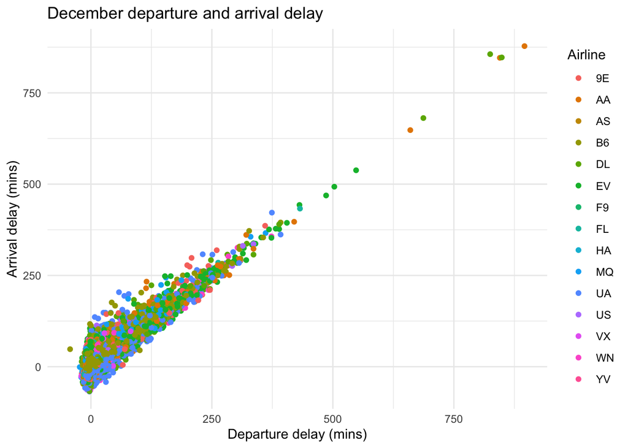

````markdown
```{r}
#| label: fig-flights-dec120

fig_flights
```
````

## 4.2 Abbildungsbeschriftung

- `fig-cap:` fügt eine Bildunterschrift ein, die im gerenderten Dokument erscheint
  - die Beschriftung immer mit Anführungszeichen umschließen! z.B., `fig-cap: "..."`

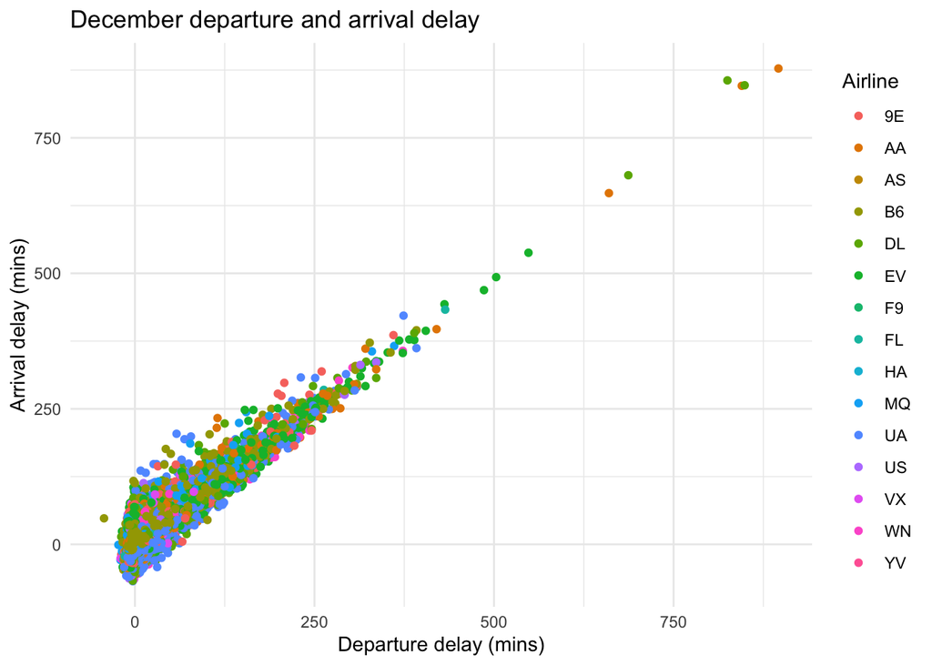

Abbildung 4: Departure delay by arrival delay for December 2013. Airline is indicated via point colour.

````markdown
```{r}
#| label: fig-flights-dec120-2
#| fig-cap: "Departure delay by arrival delay for December 2013. Airline is indicated via point colour."

fig_flights
```
````

## 4.3 Größe der Figuren

Wie wird die Größe dieser Figur aussehen?

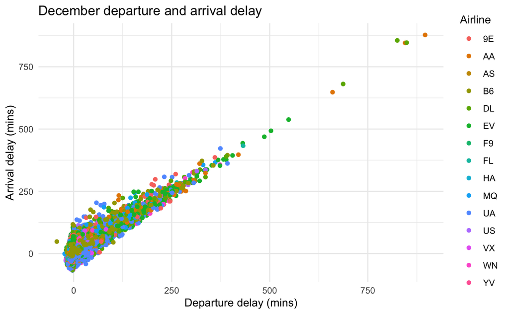

Abbildung 5: Departure delay by arrival delay for December 2013. Airline is indicated via point colour.

````markdown
```{r}
#| label: fig-flights-dec120-3
#| fig-cap: "Departure delay by arrival delay for December 2013. Airline is indicated via point colour."
#| out-width: "60%"
#| fig-asp: .618
#| fig-align: center
#| output-location: fragment

fig_flights
```
````

# 5 Querverweise

- Wir können auch im Text auf Diagramme oder Tabellen verweisen, indem wir `@` gefolgt vom `label` eingeben
  - z.B.: Dies ist ein Text, der `@fig-flights-dec120` beschreibt.

Also der Text:

> `@fig-flights-dec120-3` zeigt die Abflug- und Ankunftsverspätungen für Dezember 2013. `@fig-flights-dec120` zeigt ebenfalls diese Daten, hat aber keine Beschriftung. Die Datei `@fig-flights-dec120-2` zeigt ebenfalls diese Daten und hat eine Beschriftung, ist aber nicht vergrößert.

Wird gedruckt:

> Abbildung 5 zeigt die Abflug- und Ankunftsverspätungen für Dezember 2013. Abbildung 3 zeigt ebenfalls diese Daten, hat aber keine Beschriftung. Abbildung 4 zeigt ebenfalls diese Daten und hat eine Beschriftung, ist aber nicht vergrößert.

# 6 Aufgaben

Du hast keinen Bericht erstellt? Dann kopiere einfach den Code aus den auf Moodle geteilten Lösungen.

# Heutige Ziele 🏁

Heute haben wir…

- lernen, wie man Code Chunk Optionen verwendet ✅
- lernen, wie man die Größe von Abbildungen kontrolliert ✅
- lernen, wie man Bildunterschriften hinzufügt ✅
- lernen, wie man formatierte Tabellen druckt ✅
- lernen, wie man Querverweise erstellt ✅

# Session Info

Hergestellt mit R version 4.3.0 (2023-04-21) (Already Tomorrow) und RStudioversion 2023.3.0.386 (Cherry Blossom).

# Literaturverzeichnis

Biondo, N., Soilemezidi, M., & Mancini, S. (2022). Yesterday Is History, Tomorrow Is a Mystery: An Eye-Tracking Investigation of the Processing of Past and Future Time Reference during Sentence Reading. *Journal of Experimental Psychology: Learning, Memory, and Cognition*, *48*(7), 1001–1018. https://doi.org/10.1037/xlm0001053

Wickham, H., Çetinkaya-Rundel, M., & Grolemund, G. (o. J.). *R for Data Science* (2. Aufl.). https://r4ds.hadley.nz/